# Predicting PS status with 22q characteristics

Virgilio Gonzenbach, Joelle Jee

25 April, 2022

In this analysis, psychosis spectrum (PS) status is predicted based on 22q11.2 deletion syndrome (22q) characteristics. First, PCA is performed on the 22q sample to estimate the relative contributions, i.e. the loadings, of each gestalt score to the axes of greatest variability (PCs) in this group. These loadings are then used to compute “22q-like” factor scores for the TD and PS groups:

- ROC analysis shows **PC2 alone correctly predicts PS status 66% of the time**.
- Additionally, Bartlett’s test shows that **variance from the schizophrenia (SZ) group differs from that of clinical risk (CR) on PC2**.
- On the 22q sample, PC2 scores were associated with Psychosis Symptoms, Emotrics and MMSE scores, as well as sex and age.
- Prediction of **Schizophrenia Status** remained strong after correcting out-of-sample PC2 scores (i.e. from non-22q groups) by the above covariates. Prediction of **CR status** weakened after correction.

## 0. Sample sizes

Total sample sizes in 03/08/22 data and non-missing data per variable:

|  | 22q | CR | SZ | TD | total |
| --- | --- | --- | --- | --- | --- |
|  | 150 | 17 | 38 | 93 | 298 |
| height | 50 | 5 | 14 | 14 | 83 |
| weight | 110 | 16 | 20 | 29 | 175 |
| GAF_C | 128 | 17 | 12 | 23 | 180 |
| GAF_H | 125 | 17 | 12 | 23 | 177 |
| MMSE | 111 | 8 | 33 | 41 | 193 |
| VIQ | 76 | 0 | 0 | 0 | 76 |
| PIQ | 76 | 0 | 0 | 0 | 76 |
| FSIQ | 76 | 0 | 0 | 0 | 76 |
| DSM Dx | 150 | 0 | 0 | 0 | 150 |
| PS | 148 | 0 | 0 | 0 | 148 |

Note: Emotrics available for all records.

## 1. Examining characteristics of 22q sample with PCA

PCA was performed without scaling on the 22q sample alone.

### Scree Plot

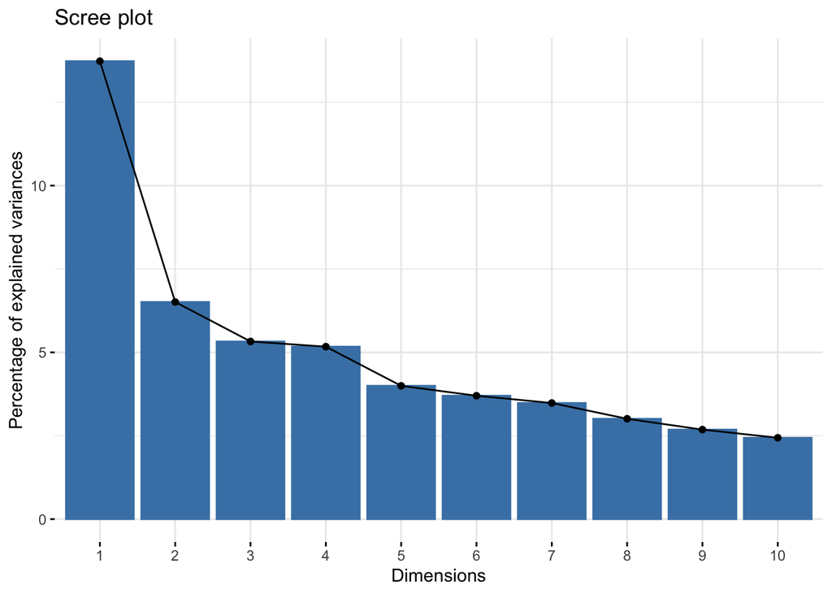

### Loadings

Loadings for the first 2 PCs are plotted below.

#### PC1

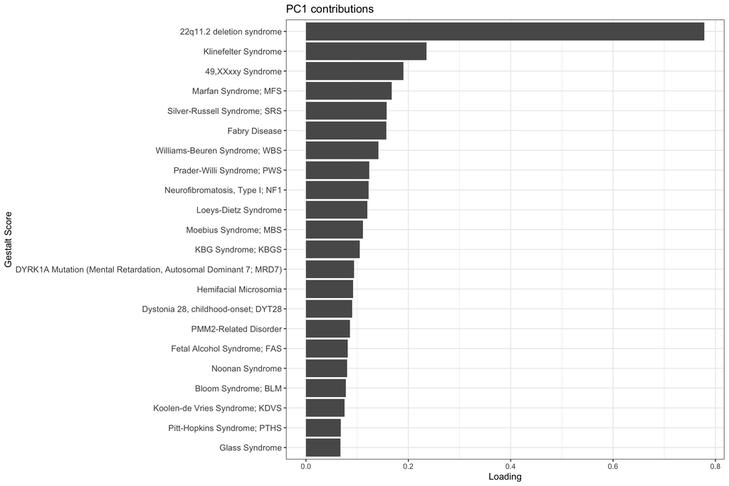

#### PC2

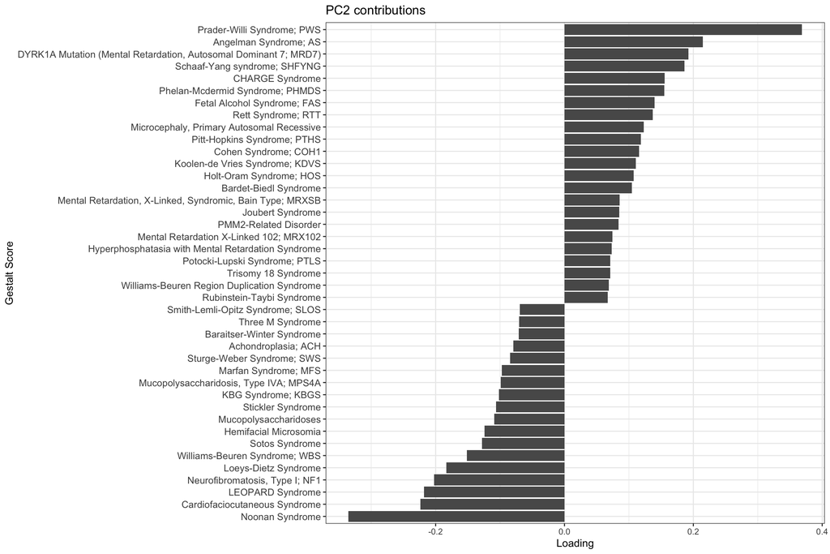

### Covariate effects on PC2 scores

#### Demographics

There were significant effects of sex and age on PC2 scores.

```
## Analysis of Variance Table
##
## Response: PC2
##            Df Sum Sq Mean Sq F value   Pr(>F)
## sex         1 0.2870 0.28702  4.9192 0.028207 *
## age         1 0.6551 0.65507 11.2270 0.001042 **
## race        4 0.3486 0.08715  1.4935 0.207518
## Residuals 137 7.9937 0.05835
## ---
## Signif. codes:  0 '***' 0.001 '**' 0.01 '*' 0.05 '.' 0.1 ' ' 1
```

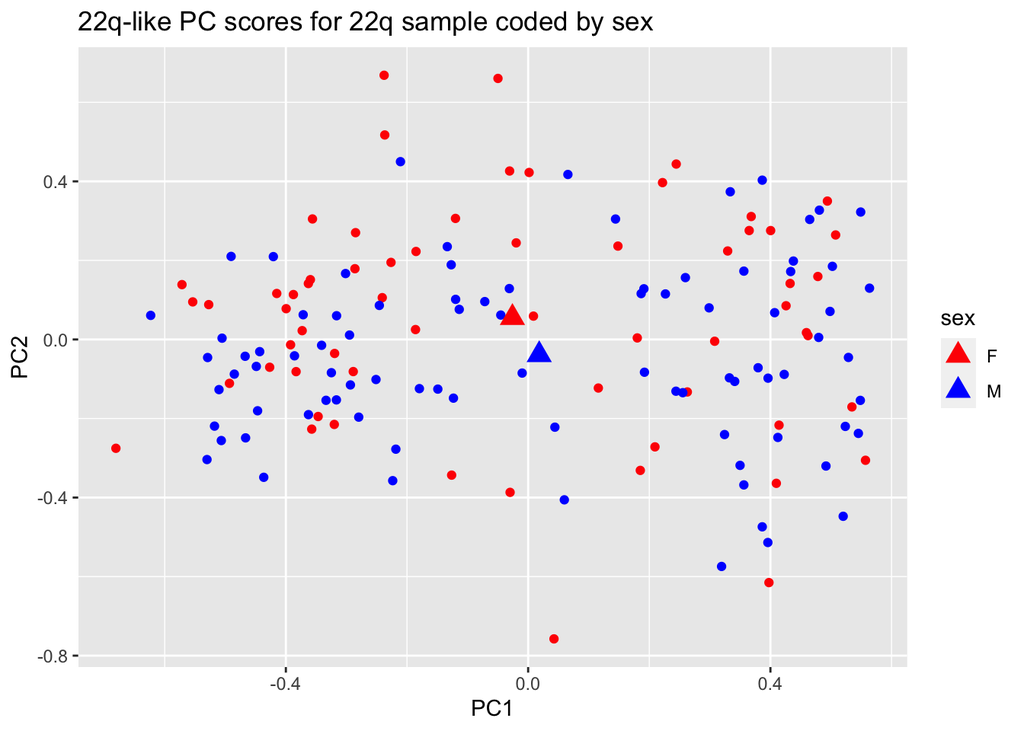

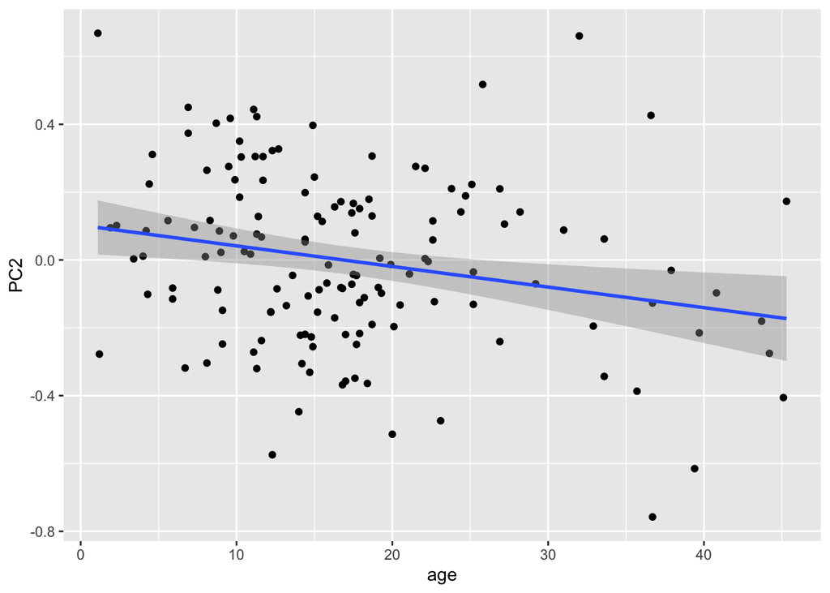

The remaining results on this section show effects on PC2 with and without adjusting for sex and age (see ‘adj PC2’).

#### Diagnosis

##### Psychosis

22q patients with psychotic symptoms had significantly higher PC2 scores than 22q patients without psychosis.

###### PC2

- PS=Yes (*M* = 0.06, *SD* = 0.26) and PS=No (*M* = -0.07, *SD* = 0.23), *t*(139.94) = 3.12, *p* = .002, *d* = 0.52

###### adj PC2

- PS=Yes (*M* = 0.05, *SD* = 0.25) and PS=No (*M* = -0.06, *SD* = 0.22), *t*(139.98) = 2.64, *p* = .009, *d* = 0.44

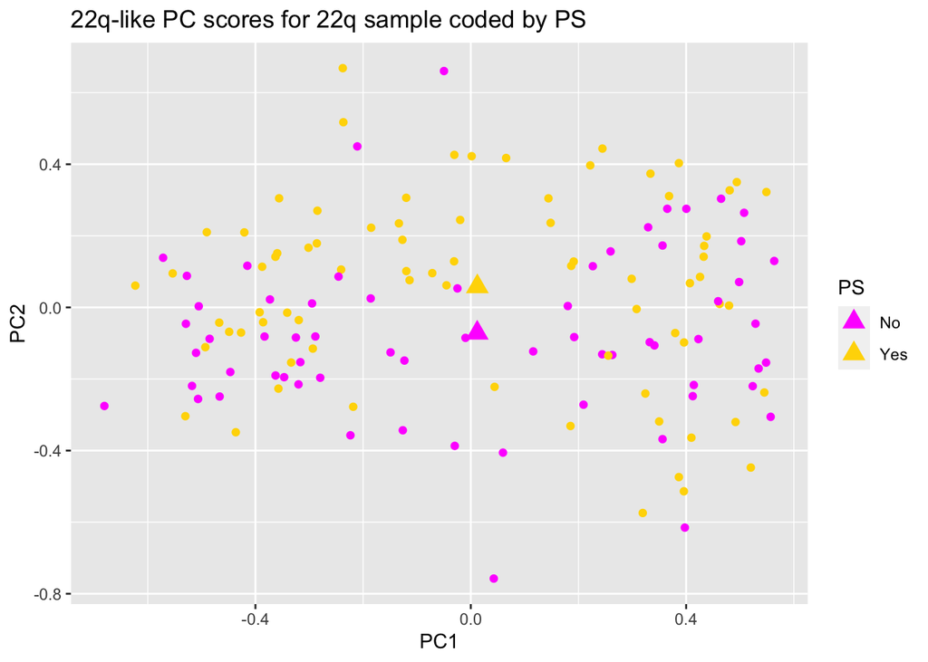

##### DSM Diagnosis

There was no effect of having a confirmed DSM diagnosis on PC2 scores

###### PC2

- DSM=Yes (*M* = 0.01, *SD* = 0.26) and DSM=No (*M* = -0.09, *SD* = 0.19), *t*(20.92) = 1.76, *p* = .093, *d* = 0.37

###### adj PC2

- DSM=Yes (*M* = 0.01, *SD* = 0.25) and DSM=No (*M* = -0.07, *SD* = 0.18), *t*(20.65) = 1.43, *p* = .167, *d* = 0.31

#### Emotrics

PC2 scores were correlated with Brow Height (Left and Right), Marginal Reflex Distance 2 (Left and Right), and Philtrum measurements. After adjustment, however, all correlations with Emotrics are significant.

|  | PC2 | p | adj PC2 | p |
| --- | --- | --- | --- | --- |
| Philtrum | -0.2994868 | 0.0005315 | -0.1856051 | 0.0259313 |
| Brow_Height | -0.3270098 | 0.0002529 | -0.2740083 | 0.0024212 |
| Marginal_Reflex_Distance_1 | -0.1608488 | 0.0541139 | -0.2171876 | 0.0119031 |
| Marginal_Reflex_Distance_2 | -0.2000212 | 0.0216414 | -0.2671083 | 0.0024212 |

#### IQ

There were no significant relationships with IQ.

|  | PC2 | p | adj PC2 | p |
| --- | --- | --- | --- | --- |
| VIQ | -0.1761879 | 0.2195111 | -0.1169501 | 0.4910731 |
| PIQ | -0.1705225 | 0.2195111 | -0.1154371 | 0.4910731 |
| FSIQ | -0.0593436 | 0.6154951 | -0.0638399 | 0.5889394 |

#### Height

There were no significant relationships with height and weight.

|  | PC2 | p | adj PC2 | p |
| --- | --- | --- | --- | --- |
| height | -0.0285254 | 0.8457355 | 0.0006505 | 0.9964606 |
| weight | 0.0488734 | 0.8457355 | 0.0461001 | 0.9964606 |

#### GAF

There were no significant relationships with GAF.

|  | PC2 | p | adj PC2 | p |
| --- | --- | --- | --- | --- |
| GAF_C | -0.1400747 | 0.1270313 | -0.1218074 | 0.1850692 |
| GAF_H | -0.1693389 | 0.1270313 | -0.1538666 | 0.1850692 |

#### MMSE

There was a significant negative relationship between PC2 and MMSE scores.

| PC2 | p | adj PC2 | p |
| --- | --- | --- | --- |
| -0.2338941 | 0.014838 | -0.2137027 | 0.0263684 |

## 2. Testing for differences between TD and PS

### 22q-like factor scores

For the Penn sample (i.e. PS and TD groups), 2 factor scores are computed using the loadings shown above as weights in a linear combination of the relevant gestalt scores.

**Note:** any reference to PCs/factor scores from this point refers to those computed for the Penn sample.

#### TD vs PS

##### PC2

PC2 shows a difference between TD and PS groups.

- TD (*M* = -0.13, *SD* = 0.16) and PS (*M* = -0.02, *SD* = 0.17), *t*(146) = -3.87, *p* < .001, *d* = -0.66

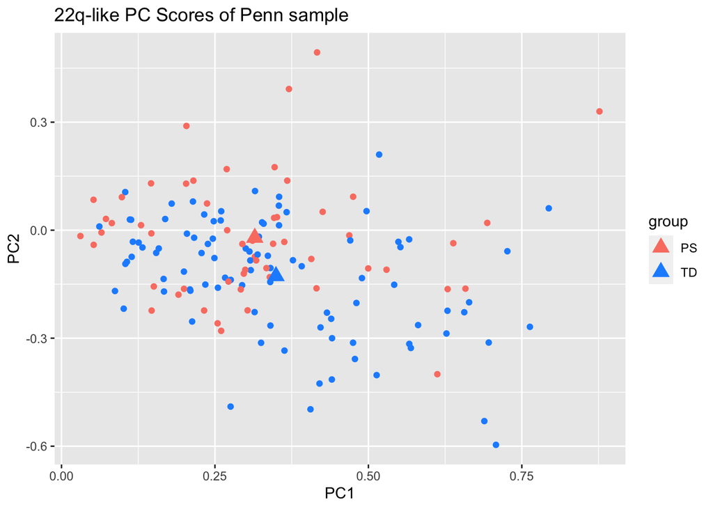

##### adj PC2

- TD (*M* = -0.01, *SD* = 0.17) and PS (*M* = 0.01, *SD* = 0.13), *t*(145) = -0.72, *p* = .472, *d* = -0.12

#### TD vs SZ

Differences remain when comparing TD only to SZ.

##### PC2

- TD (*M* = -0.13, *SD* = 0.16) and SZ (*M* = -0.01, *SD* = 0.19), *t*(128) = -3.69, *p* < .001, *d* = -0.71

There are no variance difference between these two groups.

```
##
##  Bartlett test of homogeneity of variances
##
## data:  sz_df$PC2 and sz_df$group
## Bartlett's K-squared = 2.0562, df = 1, p-value = 0.1516
```

##### adjPC2

- TD (*M* = -0.03, *SD* = 0.15) and SZ (*M* = 0.07, *SD* = 0.18), *t*(128) = -3.19, *p* = .002, *d* = -0.62

There are no variance difference between these two groups.

```
##
##  Bartlett test of homogeneity of variances
##
## data:  adjPC2 and sz_df$group
## Bartlett's K-squared = 1.0271, df = 1, p-value = 0.3108
```

#### TD vs CR

Comparison of TD with CR shows there are no differences in means

##### PC2

- TD (*M* = -0.13, *SD* = 0.16) and CR (*M* = -0.06, *SD* = 0.07), *t*(107) = -1.77, *p* = .080, *d* = -0.47

But there are variance differences.

```
##
##  Bartlett test of homogeneity of variances
##
## data:  cr_df$PC2 and cr_df$group
## Bartlett's K-squared = 10.954, df = 1, p-value = 0.000934
```

##### adjPC2

- TD (*M* = 0, *SD* = 0.15) and SZ (*M* = 0.02, *SD* = 0.08), *t*(43.99) = -0.89, *p* = .381, *d* = -0.15

#### SZ vs CR

##### PC2

No differences in means.

- SZ (*M* = -0.01, *SD* = 0.19) and CR (*M* = -0.06, *SD* = 0.07), *t*(53) = 1.05, *p* = .298, *d* = 0.31

But We see a difference in variances on PC2.

```
##
##  Bartlett test of homogeneity of variances
##
## data:  sz_cr_df$PC2 and sz_cr_df$group
## Bartlett's K-squared = 14.6, df = 1, p-value = 0.0001329
```

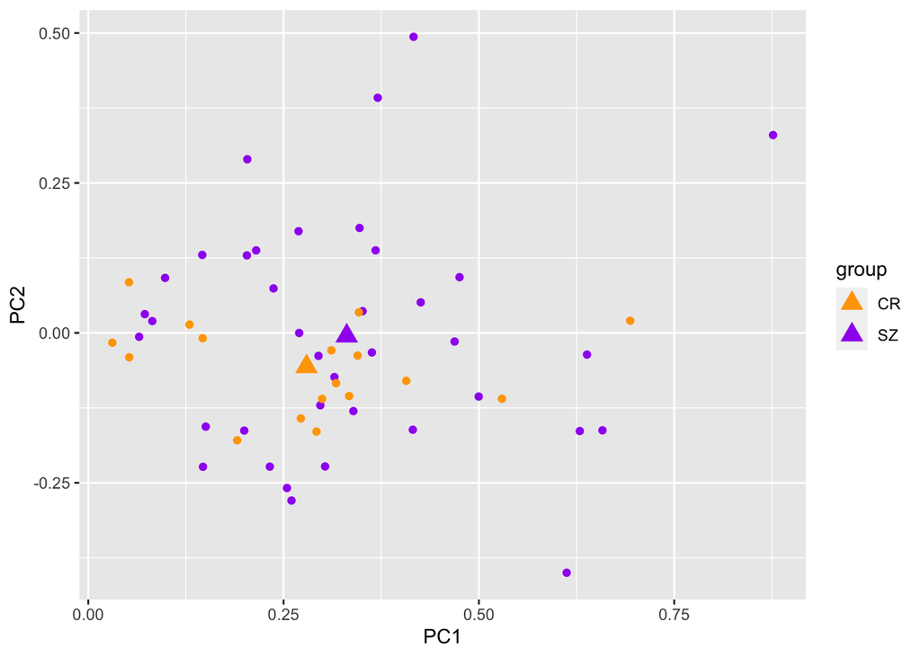

##### adjPC2

Results remain after adjustment.

- SZ (*M* = 0.02, *SD* = 0.17) and CR (*M* = -0.05, *SD* = 0.09), *t*(53) = 1.61, *p* = .114, *d* = 0.47

```
##
##  Bartlett test of homogeneity of variances
##
## data:  adjPC2 and sz_cr_df$group
## Bartlett's K-squared = 8.4351, df = 1, p-value = 0.00368
```

### Emotrics

#### PS vs TD

For PS vs TD, there were difference between groups were in Philtrum measurements and Marginal Reflex Distance 1:

- Philtrum: PS (*M* = 19.38, *SD* = 3.64) and TD (*M* = 21.54, *SD* = 3.91), *t*(146) = -3.33, *p* = .001, *d* = -0.57
- Brow Height: PS (*M* = 22.89, *SD* = 4.04) and TD (*M* = 23.52, *SD* = 4.03), *t*(146) = -0.92, *p* = .359, *d* = -0.16
- Marginal Reflex Distance 1: PS (*M* = 2.64, *SD* = 1.08) and TD (*M* = 3.38, *SD* = 0.83), *t*(146) = -4.69, *p* < .001, *d* = -0.80
- Marginal Reflex Distance 2: PS (*M* = 4.93, *SD* = 0.98) and TD (*M* = 5.12, *SD* = 0.78), *t*(146) = -1.29, *p* = .201, *d* = -0.22

#### SZ vs TD

There were differences between SZ and Td in Marginal Reflex Distance 1 but not in Philtrum measurements.

- Philtrum: SZ (*M* = 20.2, *SD* = 3.1) and TD (*M* = 21.54, *SD* = 3.93), *t*(128) = -1.88, *p* = .062, *d* = -0.36
- Brow Height: SZ (*M* = 22.95, *SD* = 4.39) and TD (*M* = 23.56, *SD* = 4.04), *t*(128) = -0.76, *p* = .451, *d* = -0.15
- Marginal Reflex Distance 1: SZ (*M* = 2.78, *SD* = 0.94) and TD (*M* = 3.39, *SD* = 0.83), *t*(128) = -3.69, *p* < .001, *d* = -0.71
- Marginal Reflex Distance 2: SZ (*M* = 4.96, *SD* = 0.76) and TD (*M* = 5.11, *SD* = 0.77), *t*(128) = -0.98, *p* = .331, *d* = -0.19

#### CR vs TD

There are differences in Philtrum and Marginal Reflex Distance 1, suggesting CR drives the PS vs TD differences in these two variables.

- Philtrum: CR (*M* = 17.57, *SD* = 4.17) and TD (*M* = 21.54, *SD* = 3.93), *t*(107) = -3.79, *p* < .001, *d* = -1.00
- Brow Height: CR (*M* = 22.77, *SD* = 3.23) and TD (*M* = 23.56, *SD* = 4.04), *t*(107) = -0.76, *p* = .448, *d* = -0.20
- Marginal Reflex Distance 1: CR (*M* = 2.34, *SD* = 1.32) and TD (*M* = 3.39, *SD* = 0.83), *t*(107) = -4.34, *p* < .001, *d* = -1.15
- Marginal Reflex Distance 2: CR (*M* = 4.87, *SD* = 1.38) and TD (*M* = 5.11, *SD* = 0.77), *t*(107) = -1.01, *p* = .314, *d* = -0.27

#### SZ vs CR

There were Philtrum differences between these two groups.

- Philtrum: SZ (*M* = 20.2, *SD* = 3.1) and CR (*M* = 17.57, *SD* = 4.17), *t*(53) = 2.60, *p* = .012, *d* = 0.76
- Brow Height: SZ (*M* = 22.95, *SD* = 4.39) and CR (*M* = 22.77, *SD* = 3.23), *t*(53) = 0.16, *p* = .877, *d* = 0.05
- Marginal Reflex Distance 1: SZ (*M* = 2.78, *SD* = 0.94) and CR (*M* = 2.34, *SD* = 1.32), *t*(53) = 1.41, *p* = .165, *d* = 0.41
- Marginal Reflex Distance 2: SZ (*M* = 4.96, *SD* = 0.76) and CR (*M* = 4.87, *SD* = 1.38), *t*(53) = 0.32, *p* = .748, *d* = 0.09

### GAF_C

GAF_C **are** significantly different between PS and TD.

- TD (*M* = 84.83, *SD* = 7.4) and PS (*M* = 59.48, *SD* = 16.94), *t*(50) = 6.68, *p* < .001, *d* = 1.86

### GAF_H

GAF_H **are** significantly different between PS and TD.

- TD (*M* = 85.26, *SD* = 6.96) and PS (*M* = 61.69, *SD* = 17.3), *t*(50) = 6.14, *p* < .001, *d* = 1.71

### Height

No significant difference.

- TD (*M* = 66.07, *SD* = 4.39) and PS (*M* = 66.89, *SD* = 3.86), *t*(31) = -0.57, *p* = .572, *d* = -0.20

### Weight

No significant difference.

- TD (*M* = 167.66, *SD* = 42.04) and PS (*M* = 174.17, *SD* = 39.44), *t*(63) = -0.64, *p* = .523, *d* = -0.16

### MMSE

No significant difference.

- TD (*M* = 28.56, *SD* = 1.57) and PS (*M* = 26.93, *SD* = 5.27), *t*(80) = 1.90, *p* = .061, *d* = 0.42

## 3a. Predicting PS status based on 22q-like PC2

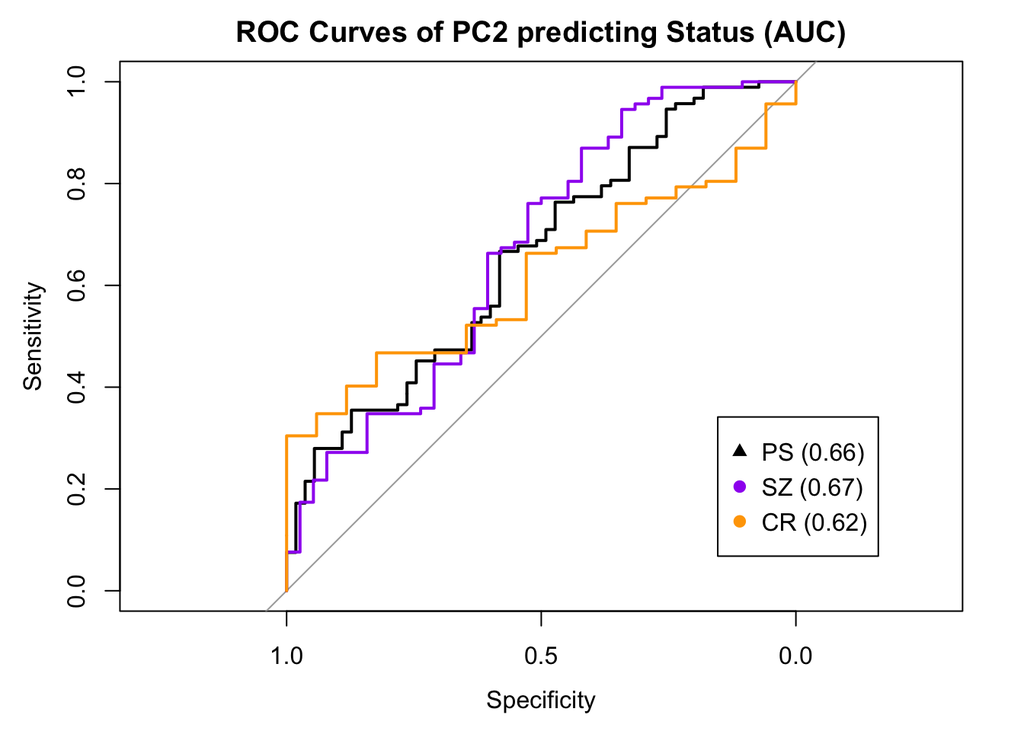

#### Psychosis Status

95% CI: 0.5678-0.7484 (DeLong)

#### Schizophrenia Status

95% CI: 0.5638-0.7788 (DeLong)

#### Clinical Risk Status

95% CI: 0.5002-0.7364 (DeLong)

## 3b. Predicting PS status based on Emotrics

Prediction by the 4 (aggregated) Emotrics variables is significant for every status. Relative to prediction by PC2, prediction of SZ by emotrics is slightly weaker but CR prediction has improved.

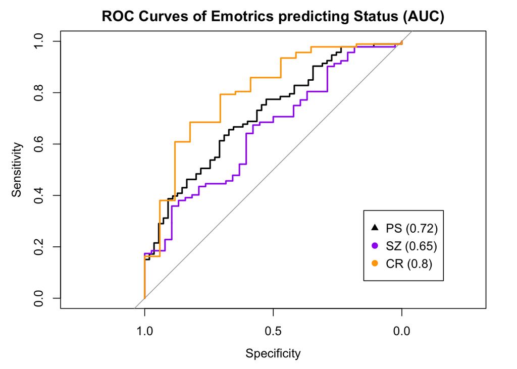

#### Psychosis Status

95% CI: 0.6326-0.8 (DeLong)

#### Schizophrenia Status

95% CI: 0.5518-0.7549 (DeLong)

#### Clinical Risk Status

95% CI: 0.6814-0.9222 (DeLong)

## 3c. Predicting PS status with 22q-like PC2 and emotrics

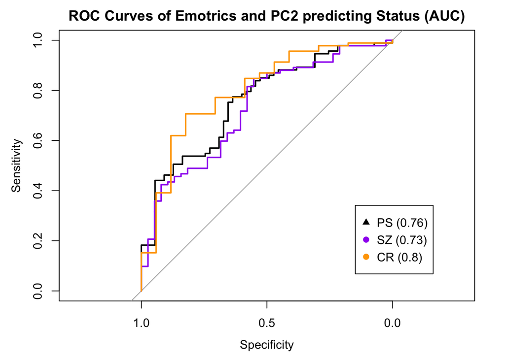

#### Psychosis Status

95% CI: 0.678-0.836 (DeLong)

#### Schizophrenia Status

95% CI: 0.6368-0.8254 (DeLong)

#### Clinical Risk Status

95% CI: 0.6795-0.919 (DeLong)

## 4. Predicting PS status based on adjusted PC2

### PC2 Sex and age adjustment

Prediction strength for PS status drops slightly after adjustment. However, prediction of CR status becomes essentially random (see CI).

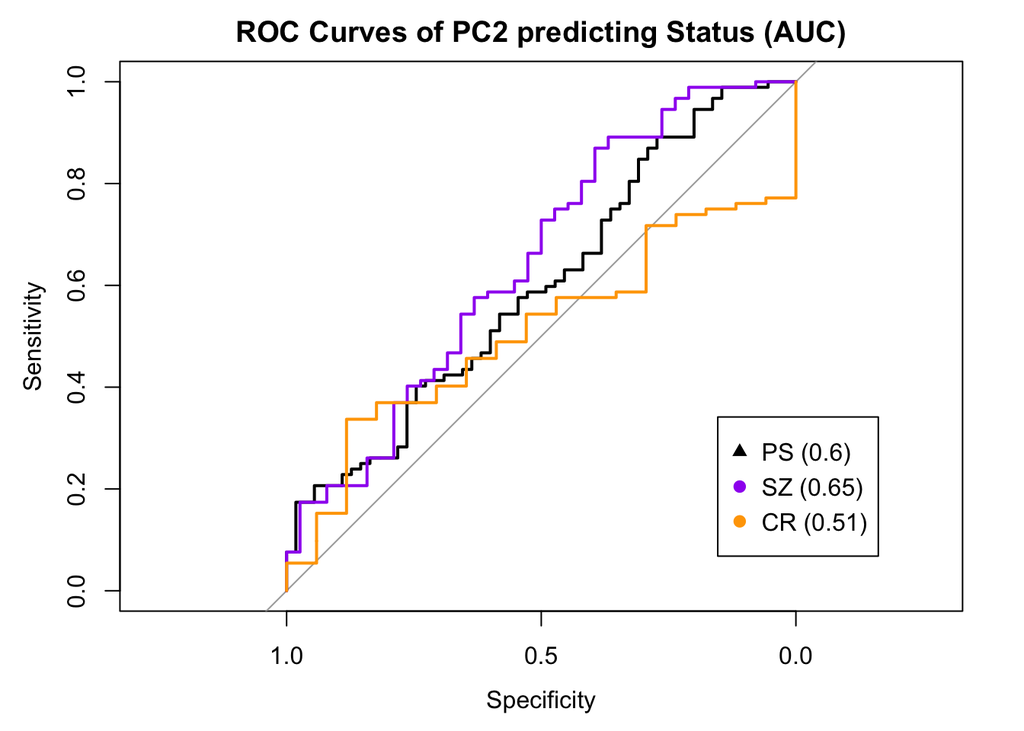

#### Psychosis Status

95% CI: 0.5033-0.6931 (DeLong)

#### Schizophrenia Status

95% CI: 0.5373-0.7551 (DeLong)

#### Clinical Risk Status

95% CI: 0.383-0.6349 (DeLong)

### PC2 Emotrics-adjusted scores

After adjusting PC2 for emotrics, prediction of SZ-status remains strong while CR becomes random.

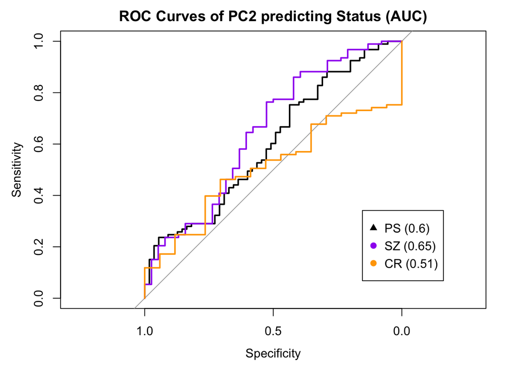

#### Psychosis Status

95% CI: 0.5072-0.6967 (DeLong)

#### Schizophrenia Status

95% CI: 0.5417-0.7599 (DeLong)

#### Clinical Risk Status

95% CI: 0.3824-0.6322 (DeLong)

### High missingness drops AUC

#### GAF_C

Excluding observations with missing data on GAF_C, drops AUC to random levels (i.e. CI includes .50) pointing to insufficient data. No adjustment was applied to PC2 scores.

| 22q | CR | SZ | TD | total |
| --- | --- | --- | --- | --- |
| 128 | 17 | 12 | 23 | 180 |

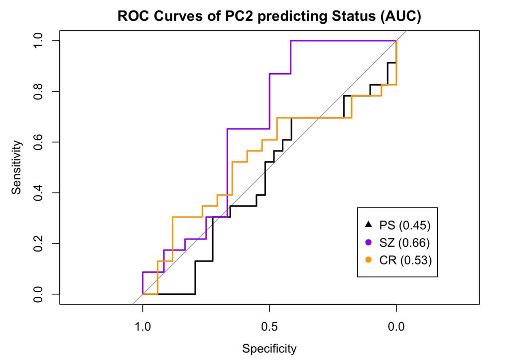

##### Psychosis Status

95% CI: 0.2903-0.6123 (DeLong)

##### Schizophrenia Status

95% CI: 0.4409-0.8852 (DeLong)

##### Clinical Risk Status

95% CI: 0.3469-0.7171 (DeLong)

#### GAF_H

Excluding observations with missing data on GAF_H, drops AUC. No adjustment was applied to PC2 scores.

[output not shown]

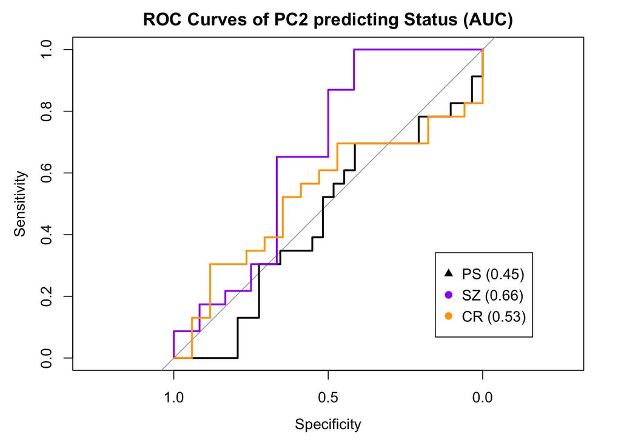

##### Psychosis Status

95% CI: 0.2903-0.6123 (DeLong)

##### Schizophrenia Status

95% CI: 0.4409-0.8852 (DeLong)

##### Clinical Risk Status

95% CI: 0.3469-0.7171 (DeLong)

#### MMSE

Excludding observations with missing data on MMSE. No adjustment was applied to PC2 scores.

| 22q | CR | SZ | TD | total |
| --- | --- | --- | --- | --- |
| 111 | 8 | 33 | 41 | 193 |

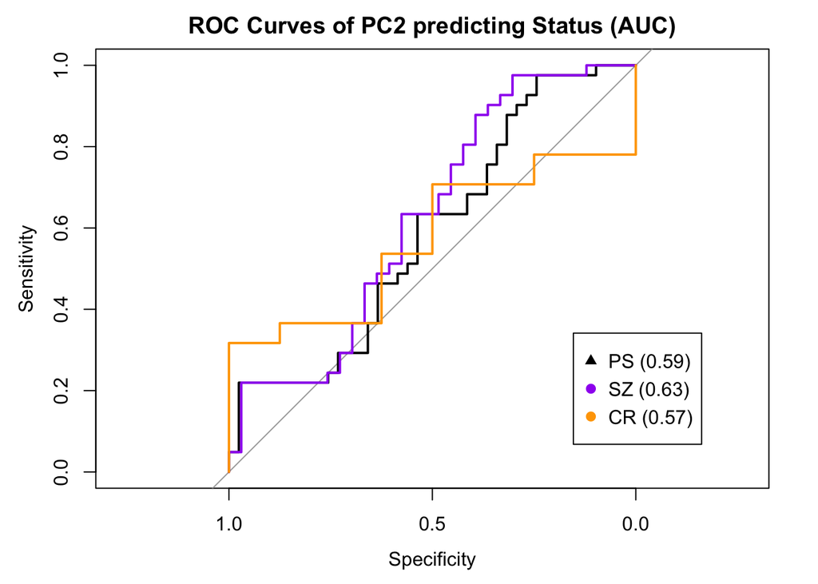

##### Psychosis Status

95% CI: 0.4626-0.7129 (DeLong)

##### Schizophrenia Status

95% CI: 0.4933-0.7588 (DeLong)

##### Clinical Risk Status

95% CI: 0.3895-0.7507 (DeLong)